# LWBS

Linping

6/21/2018

In this section, we will take a look at the characteristics of patients labeled as Left Without Being Seen(LWBS).

We first take a look at how the LWBS rate is distributed across years.

## LWBS rate across years

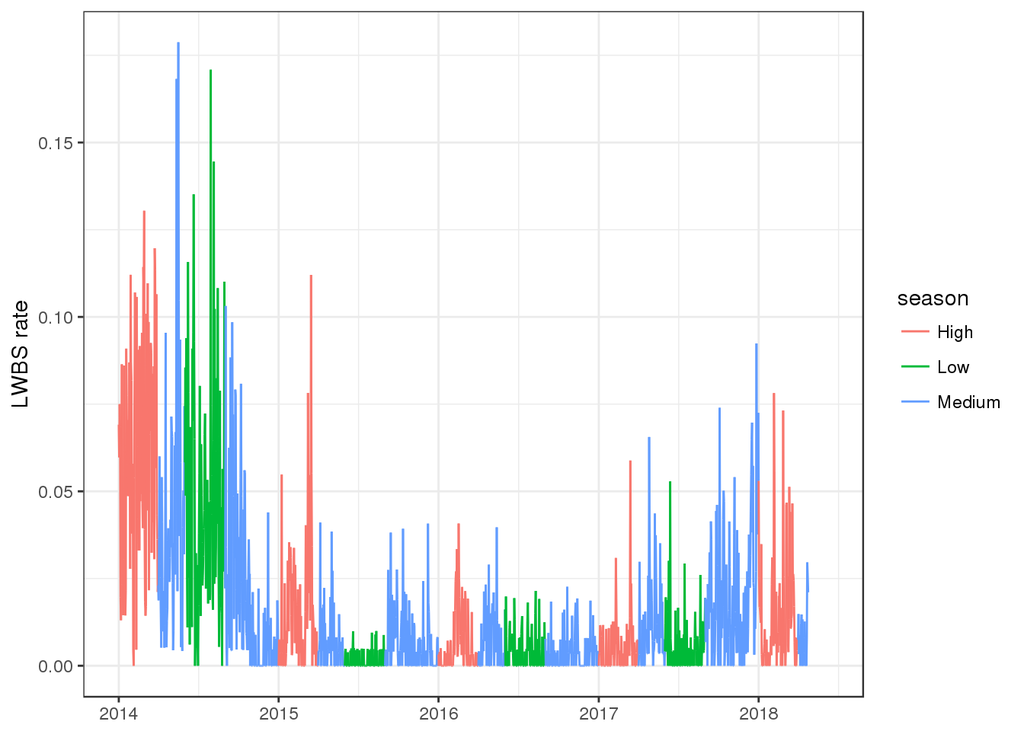

## How did acuity level affect the likelihood of leaving?

Generally, we think patient with high acuities will choose not to leave until they got fully cured.

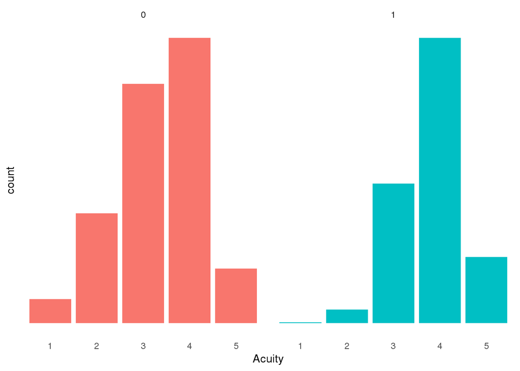

The above graph showed the different distribution pattern of regular patient and patient with LWBS label. Low acuity patients take more percentage in the total distribution. In other words, lower acuity patients have a stronger likelihood to leave without been seen by a physician (get fully cured).

## How did financial class affect the likelihood of leaving?

The financial class mostly represents the type of insurance that the patient had. Because the insurance will have direct impact on how much the patient would pay for the service, it will also impact the decision to leave because of too much a payment or lack of ability to pay.

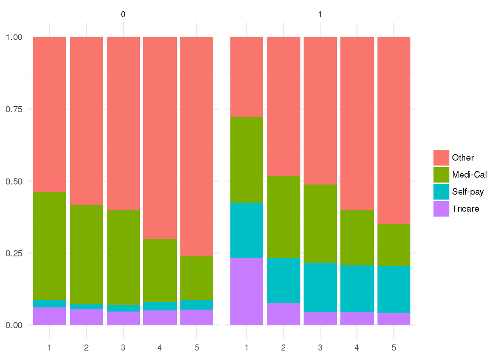

The above graph revealed that, patients with **Tricare** as their insurance are more likely to leave when they have extreme high acuity. But this did not happen too much since we only observed very few LWBS with acuity level 1 from the previous graph. But what’s more significant is, patients with no insurance, namely **self-pay** patients, are much more likely to leave in any situation.

## How many patients LWBS before roomed in ED?

We want to see if people would leave because they have been waiting in the waiting room for too long.

```
          0           1
0.001952489 0.998047511
```

The label 0 represents that there was not a event named “Patient roomed in ED” in the `event` records, label 1 represents the opposite.

There is only 0.2 percent LWBS not roomed in ED. So it is not the case that a long wait in the waiting room cause the leave, as long as the patient had already registered. But this percentage analysis has limitations. One major of those is that we cannot catch and count those who did not registered but leave after seeing so many people waiting in the waiting room.

## How many patients LWBS after seen by a physician?

```
        0         1
0.8957045 0.1042955
```

The label 0 represents that there was not a event named “Assign Attending” in the `event` records, label 1 represents the opposite.

Around 10% LWBS seen patients left after seen by a physician. This percentage is siginificantly larger. One possibile reason is that patient leave because they spent too long time in bed waiting for a physician to come. But when they felt their conditions were not that bad at all, they just left to save time and money.

In the following section, we will dig into the timeline of patients labeled as LWBS.

## Timeline

In plots below, the size of the point represents the number of observations. The larger the points, the more confident we are to generalized it.

### How much time on average LWBSs spent between arrival and triage complete?

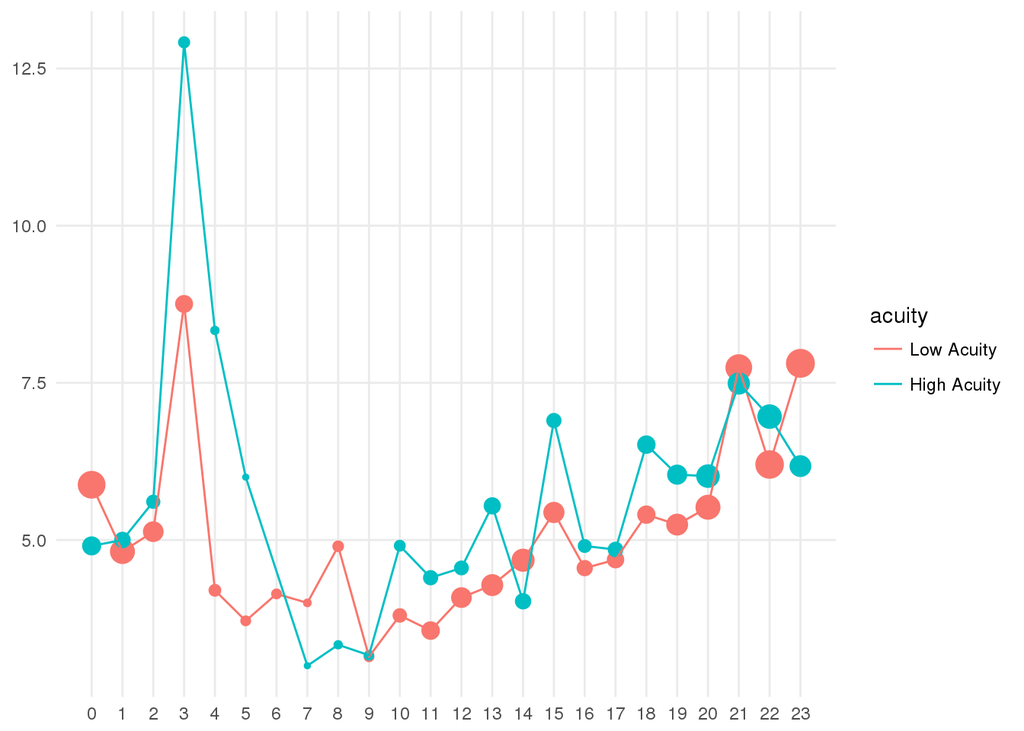

#### How much time on average they spent between triage complete and roomed

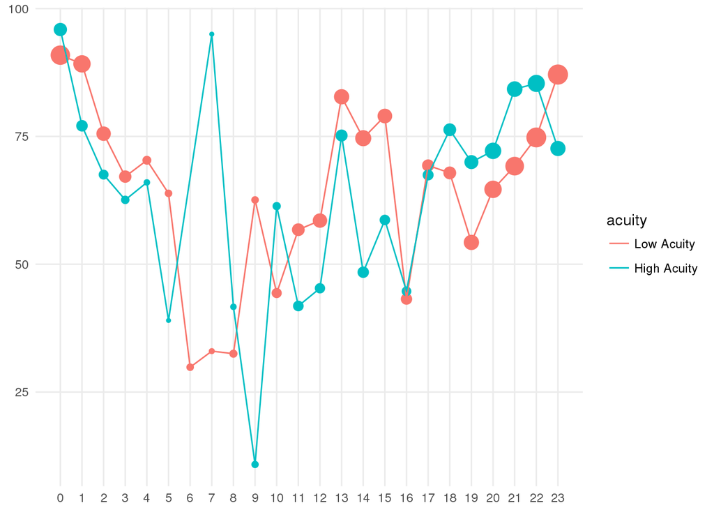

#### How much time on average they spent between roomed and left

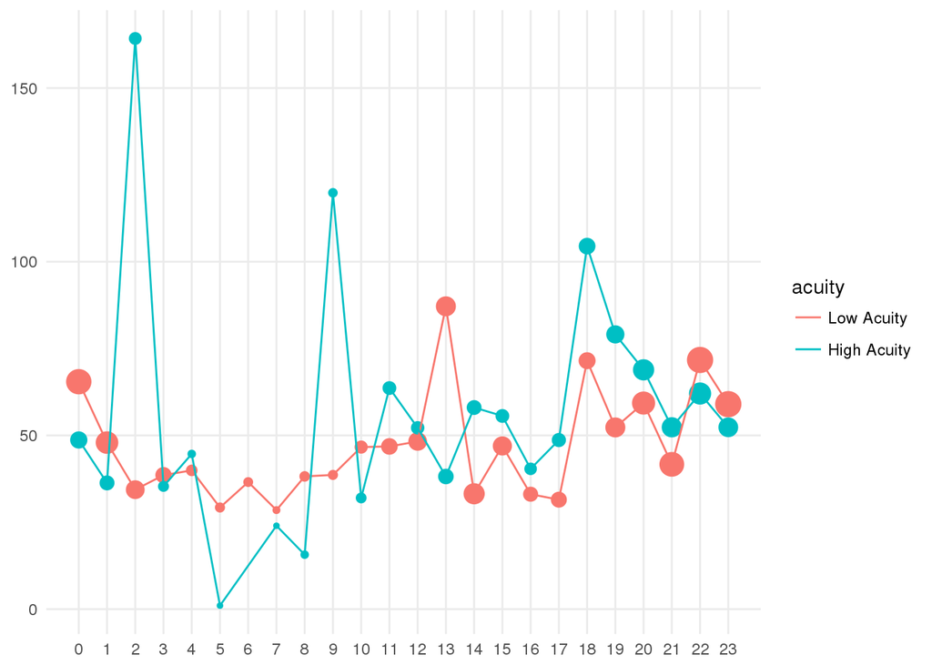

The three plots shown above revealed that the majority of time a patient labeled with LWBS spent on is waiting to be roomed. Since only 0.2% LWBS patients left before roomed, this was not a huge problem.

How about compare the time spent waiting for a physician of regular patients and patients labeled as LWBS?

#### Percentage patient (did not leave) wait longer than LWBS

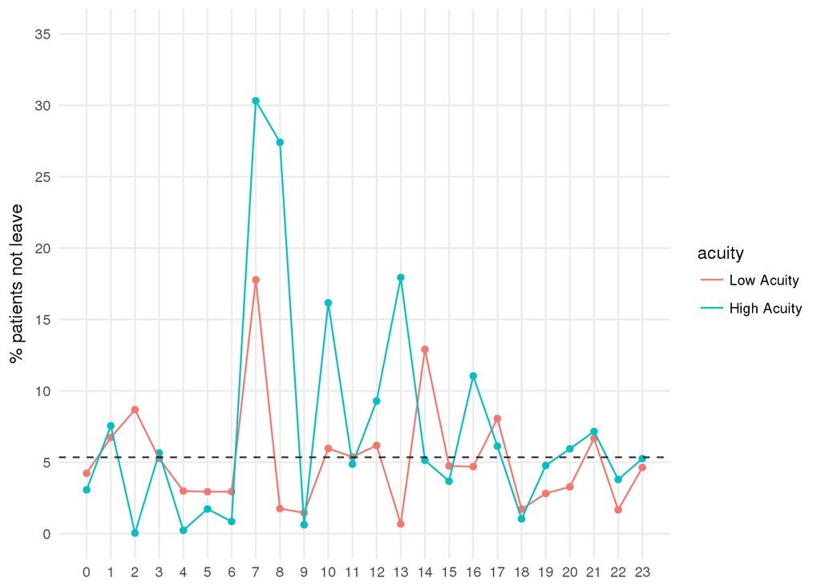

We assume the time a patient labeled with LWBS left to be the time the physician was assigned. Then we are able to compare the length of two different time gaps.

- The time gap between roomed and assigned physician for a patient not labeled with LWBS. For simplicity, we called this type of patients NL patients
- The time gap between roomed and left for a patient labeled with LWBS. We called this type of patients L patients.

### 120 minutes

If we made a policy that every patient should have at least a physician assigned within 120 minutes after roomed:

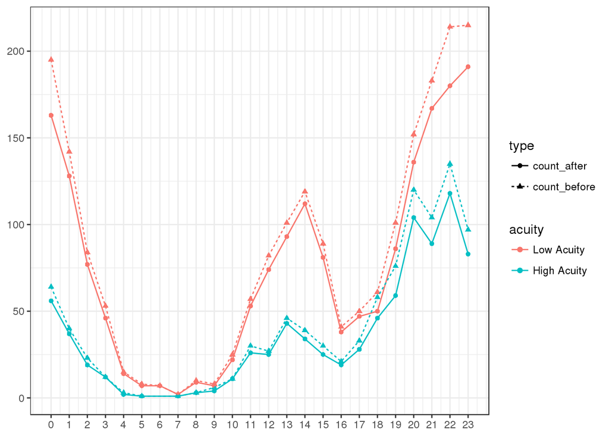

We can expect a 11.99% reduction in number of LWBS patients.

### 90 minutes

If we made a policy that every patient should have at least a physician assigned within 90 minutes after roomed:

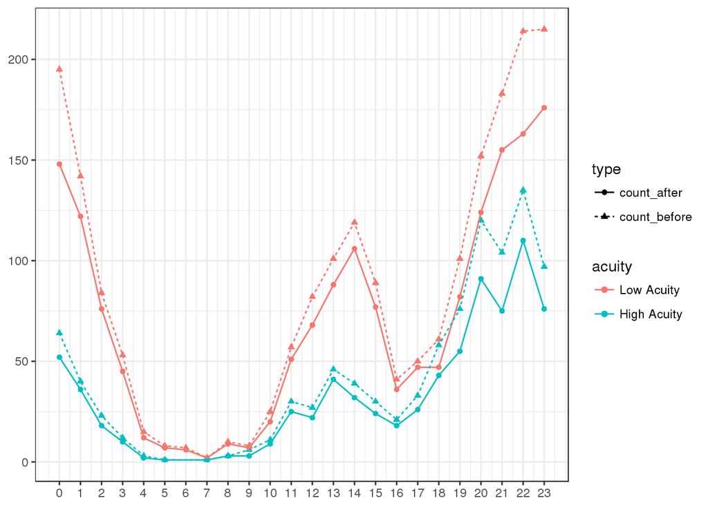

We can expect a 18.27% reduction in number of LWBS patients.

### 60 minutes

If we made a policy that every patient should have at least a physician assigned within 60 minutes after roomed:

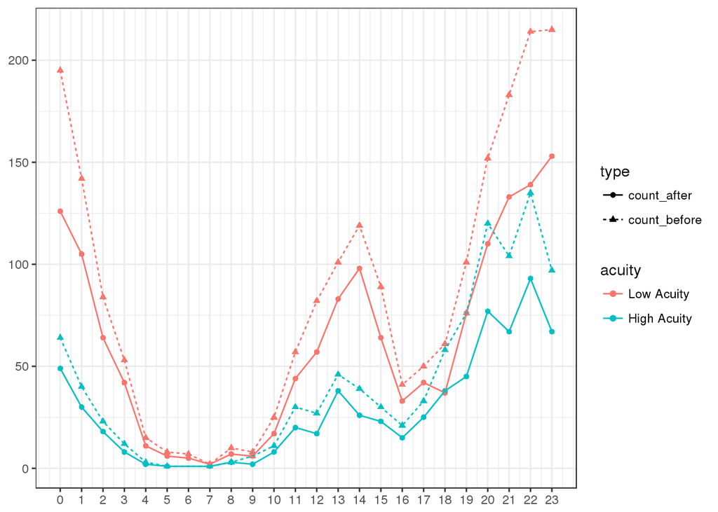

We can expect a 28.76% reduction in number of LWBS patients.

### Average minutes waiting of the non-LWBS pateints

If we made a policy that every patient should have at least a physician assigned within the average wait time for a NP patients to be seen by a physician after roomed, which is around 39.09 minutes:

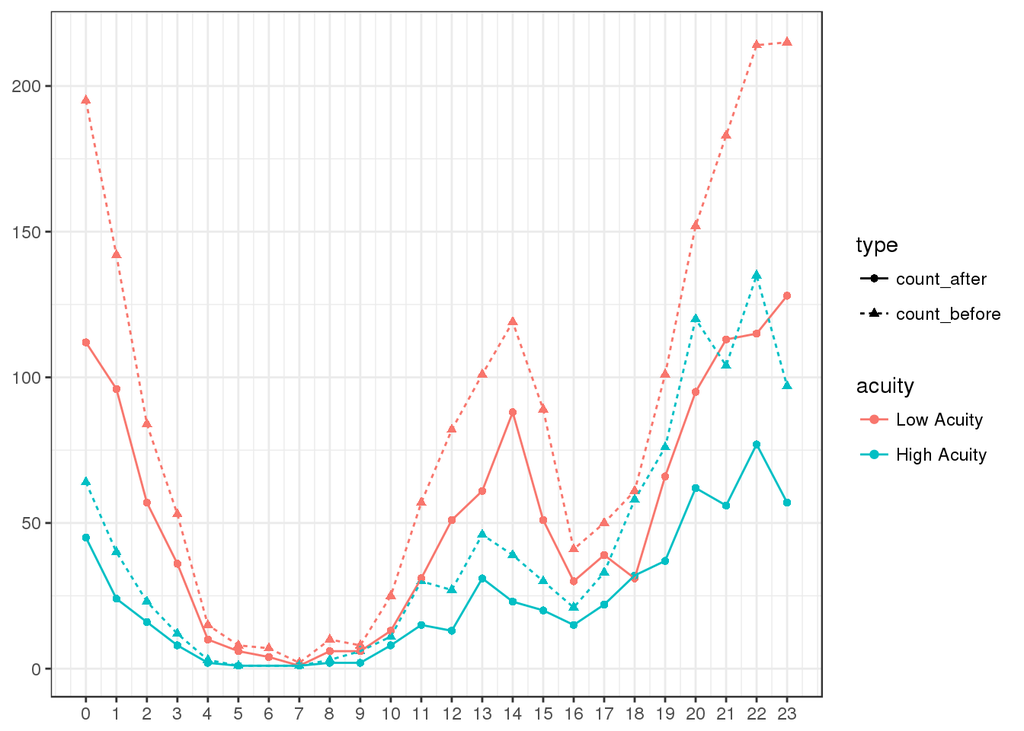

We can expect a 39.38% reduction in number of LWBS patients.